# machine_learning

## Model Training and Evaluation

```python
import pandas as pd
import numpy as np
import mlflow
import tempfile
import IPython.display
import pathlib
import pickle
import time
import matplotlib.pyplot as plt

import sklearn
import sklearn.model_selection
import sklearn.impute
import sklearn.ensemble
import sklearn.pipeline
import sklearn.tree
import sklearn.metrics
import sklearn.neural_network
import sklearn.preprocessing
import sklearn.compose
from sklearn.feature_selection import SelectKBest, chi2

import ml_colon
import ml_colon.data_preparation
```

### Retrieving Data

We have implemented the data cleaning the `ml_colon.data_preparation` module and with that retrieve the "cleaned" DataFrame. By "cleaned" we mean that we have filtered out all rows that we want to exclude from training.

```python
df = ml_colon.data_preparation.get_clean_df_from_csv()

print(f"Loaded data set with {len(df)} rows.")
```

```
Loaded data set with 15967 rows.
```

### Splitting Train / Test set

Next we split the data set into the train / test set.

```python
test_size = 0.2 # 20% of rows
possible_features = [c for c in df.columns if c != ml_colon.TARGET_VARIABLE]

X_train, X_test, y_train, y_test = sklearn.model_selection.train_test_split(
    df[possible_features],
    df[ml_colon.TARGET_VARIABLE],
    test_size=test_size,
    random_state=ml_colon.SEED,
)

print(f"Train set: {len(y_train)} rows | Test set: {len(y_test)} rows\n")
print(f"Train set grouped by relevant: \n{y_train.value_counts()}\n")
print(f"Test set grouped by relevant: \n{y_test.value_counts()}")
```

```
Train set: 12773 rows | Test set: 3194 rows

Train set grouped by relevant:
1.0    10493
0.0     2280
Name: relevant, dtype: int64

Test set grouped by relevant:
1.0    2633
0.0     561
Name: relevant, dtype: int64
```

#### Upsampling

Where are dealing with an imbalanced data set regarding the target variable. Any estimator can reach 82% accuracy by simply always predicting 1. Reminder that: \begin{equation} accuracy = \dfrac{TP + TN}{P + N} \end{equation}

Therefore we need to upsample the rows in our dataframe with relevant = 0

```python
def upsample(df: pd.DataFrame, n: int) -> pd.DataFrame:
    """Upsample the DataFrame with respect to the target variable "relevant".

    Parameters
    ----------
    df : pd.DataFrame
        [description]
    n : int
        number of rows in resulting DataFrame

    Returns
    -------
    pd.DataFrame
        the upsampled DataFrame
    """
    weight_relevant_1 = 0.5 / len(df[df.relevant == 1] )
    weight_relevant_0 = 0.5 / len(df[df.relevant == 0] )

    relevant_weighted = df.relevant.replace({
        0: weight_relevant_0,
        1: weight_relevant_1
    })
    return df.sample(
        n=n,
        replace=True,
        weights=relevant_weighted
    )
```

```python
train_df = X_train
train_df[ml_colon.TARGET_VARIABLE] = y_train

train_df = upsample(train_df, n=len(X_train))

X_train = train_df[possible_features]
y_train = train_df[ml_colon.TARGET_VARIABLE]

print(f"Train set: {len(y_train)} rows")
print(f"Train set grouped by relevant: \n{y_train.value_counts()}\n")
```

```
Train set: 12773 rows
Train set grouped by relevant:
1.0    6392
0.0    6381
Name: relevant, dtype: int64
```

### Feature Selection

To speed up the model training and for the beginning have "simpler" and potentially more explainable models we limit the numbers of features / columns we use.

```python
selection = SelectKBest(score_func = chi2, k = 10).fit(X_train, y_train).get_support()
features = [i for (i, boolean) in zip(possible_features, selection) if boolean]

X_train_limited_features = X_train[features].copy()
X_test_limited_features = X_test[features].copy()
```

```python
print(f"Columns to be used as features: {features}")
```

```
Columns to be used as features: ['bits', 'non_zero_pixels', 'frame_width', 'frame_height', 'movement_level', 'variance', 'var_movement_h', 'var_movement_v', 'cost_1', 'cost_2']
```

As already described in the `data_exploration.ipynb` notebook these are the 10 feature that will hopefully yield the best results.

### Classifiers and Parameters Definition

We will try different models to get the best outcome with different hyperparameters based on the accuracy of the model. The different classifiers used are:

- K-Nearest Neighbor
- Random Forest
- Multi-Layer Perceptron
- Gradient Boosting

With this selection, there is a variety of complexity of models used. There is one simple model, namely the K-Nearest Neighbor algorithm. The Random Forest algorithm is an ensemble method and a more powerful method than K-Nearest Neighbors. Nowadays, there is a big hype around neural networks and their power of finding interesting patterns in data, therefore the Multi-Layer Perceptron is included. Lastly, we used also a gradient boosting classifier which is as well an ensemble method and similar to Random Forest.

Each of these algorithms will be tested with different hyperparameters using grid search. The different values of the parameters are described below.

```python
implemented_classifiers = {
    "k_neighbor": {
        "classifier": sklearn.neighbors.KNeighborsClassifier(),
        "param_grid": [{"classifier__n_neighbors": [3, 5, 11, 15, 20]}],
    },
    "random_forest": {
        "classifier": sklearn.ensemble.RandomForestClassifier(max_features=2),
        "param_grid": [{"classifier__max_depth": [4, 8, 10, 12, 14, 16, 18, 20], "classifier__n_estimators": [10, 15, 20, 25, 30, 35, 40, 45, 50, 55]}],
    },
    "multilayer_perceptron": {
        "classifier": sklearn.neural_network.MLPClassifier(),
        "param_grid": [
            {"classifier__alpha": [0.001, 0.01, 0.1, 0.5], "classifier__activation": ["identity", "relu"]}
        ],
    },
    "gradient_boosting": {
        "classifier": sklearn.ensemble.GradientBoostingClassifier(),
        "param_grid": [
            {"classifier__learning_rate": [ 0.05, 0.1, 0.2], "classifier__n_estimators": [100, 150, 200]}
        ]

    }
}
```

#### Model Pipeline

Before a machine learning model can be trained some data transformations need to be done. For that we use a `sklearn.pipeline.Pipeline` to chain the data transformations such as imputing missing values or scaling.

```python
def build_model_pipeline(classifier: str, X_train: pd.DataFrame) -> sklearn.pipeline.Pipeline:
    index_continous_columns = X_train.columns.get_indexer(
        X_train.select_dtypes(include=np.float).columns
    )

    pipeline = sklearn.pipeline.Pipeline(
        steps=[
            (
                "imputer", sklearn.impute.SimpleImputer(missing_values=np.nan, strategy="mean") # this is not strictly necessary as we throw out all rows with missing values in the data cleaning
            ),
            (
                "scaler", sklearn.compose.make_column_transformer(
                    (
                        sklearn.preprocessing.MinMaxScaler(feature_range=(0,1)),
                        index_continous_columns
                    ),
                    remainder="passthrough"
                )
            ),
            (
                "classifier",
                implemented_classifiers[classifier]["classifier"],
            ),
        ]
    )

    return pipeline
```

#### Grid Search

```python
def build_grid_search(pipeline: sklearn.pipeline.Pipeline) -> sklearn.model_selection.GridSearchCV:
    classifier_cv = sklearn.model_selection.GridSearchCV(
        estimator=pipeline,
        param_grid=implemented_classifiers[classifier]["param_grid"],
        scoring=score_metric,
    )
    return classifier_cv
```

### Model Training and Evaluation

We use [mlflow](https://www.mlflow.org/) library to track each model training and save the resulting plots.

```python
mlflow.set_tracking_uri("file://" + str(ml_colon.OUTPUT_DIR / "mlruns"))
tracking_uri = mlflow.get_tracking_uri()
print("Current tracking uri: {}".format(tracking_uri)) # where the outputs are stored

trained_models = [] # a list to store the trained models
```

```
Current tracking uri: file:///home/agemcipe/personal_dump/data_processes_mlcolonoscopy/output/mlruns
```

```python
def run_model(
    classifier:str,
    X_train: pd.DataFrame,
    y_train: pd.Series,
    X_test: pd.DataFrame,
    y_test: pd.Series
    ):
    start_time = time.time()

    pipeline = build_model_pipeline(classifier, X_train)
    classifier_cv = build_grid_search(pipeline)

    run_id = None
    with mlflow.start_run() as run:

        run_id = run.info.run_id
        experiment_id = run.info.experiment_id
        print(f"Starting MlFlow run {run_id} for experiment {experiment_id}", "\n")

        mlflow.log_param("classifier", classifier)
        mlflow.log_param("number_of_features", len(X_train.columns))
        mlflow.log_param("number_of_rows_train", len(X_train))
        mlflow.log_param("number_of_rows_test", len(X_test))

        # The training of the model
        print(f"Training a {classifier} classifier")
        classifier_cv.fit(X_train, y_train)

        # Best parameters
        print("Best parameters:")
        print(classifier_cv.best_params_, "\n")

        mlflow.log_params(classifier_cv.best_params_)
        mlflow.log_metric(score_metric, classifier_cv.best_score_)

        # Evaluation of results
        print("Classification Report")
        y_pred = classifier_cv.predict(X_test)
        y_pred_proba = classifier_cv.predict_proba(X_test)
        report = sklearn.metrics.classification_report(y_test, y_pred, output_dict=True)

        IPython.display.display(pd.DataFrame(report).T)

        for label in ["0.0", "1.0"]:
            for k, v in report[label].items():
                mlflow.log_metric(f"label_{label}_{k}", v)


        print("Plotting Confusion Matrix")
        cm = sklearn.metrics.confusion_matrix(y_test, y_pred)
        cm_fig = sklearn.metrics.ConfusionMatrixDisplay(cm).plot()
        plt.show()

        print("Plotting ROC curve")
        roc_fig = sklearn.metrics.plot_roc_curve(
            classifier_cv, X_test, y_test, name=f"ROC Curve {classifier}"
        )
        plt.show()

        print("Writing Artifacts to MlFlow")
        with tempfile.TemporaryDirectory() as tmp_dir:
            tmp_dir_path = pathlib.Path(tmp_dir)
            assert tmp_dir_path.exists()

            # Saving plots
            cm_fig.figure_.savefig(str(tmp_dir_path / "confusion_matrix.png"))
            roc_fig.figure_.savefig(str(tmp_dir_path / "roc.png"))

            # Saving Model
            with open(tmp_dir_path / "model.pkl", "wb") as model_file:
                pickle.dump(classifier_cv, model_file)

            mlflow.log_artifacts(str(tmp_dir_path))

        # store trained model in list for later evaluation
        trained_models.append({
            "name": classifier,
            "classifier": classifier_cv,
            "features": list(X_train.columns),
            "X_test": X_test,
            "y_test": y_test
            })

        run_time = time.time() - start_time
        mlflow.log_metric("run_time_in_seconds", run_time)
        print(f"Finished in {run_time} seconds")

    return run_id, experiment_id
```

#### It's time for training!

We want to train each classifier. One time with the preselected features and one time with all columns as input

```
Starting MlFlow run b2b3f2d936b04ea49c66e8a3f09c4fcf for experiment 1

Training a k_neighbor classifier
Best parameters:
{'classifier__n_neighbors': 3}

Classification Report
```

|  | precision | recall | f1-score | support |
| --- | --- | --- | --- | --- |
| 0.0 | 0.284412 | 0.556150 | 0.376357 | 561.000000 |
| 1.0 | 0.881259 | 0.701861 | 0.781395 | 2633.000000 |
| accuracy | 0.676268 | 0.676268 | 0.676268 | 0.676268 |
| macro avg | 0.582835 | 0.629005 | 0.578876 | 3194.000000 |
| weighted avg | 0.776428 | 0.676268 | 0.710254 | 3194.000000 |

```
Plotting Confusion Matrix
```

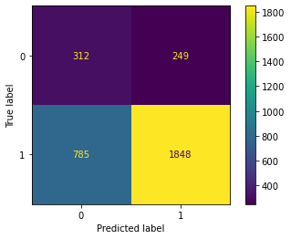

```
Plotting ROC curve
```

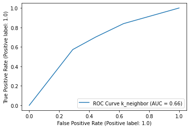

```
Writing Artifacts to MlFlow
Finished in 2.9354300498962402 seconds
-------------------------------------------------------
Starting MlFlow run 1045cdcf836f4ad3ae1682aa6f9a26be for experiment 1

Training a random_forest classifier
Best parameters:
{'classifier__max_depth': 20, 'classifier__n_estimators': 45}

Classification Report
```

|  | precision | recall | f1-score | support |
| --- | --- | --- | --- | --- |
| 0.0 | 0.405874 | 0.541889 | 0.464122 | 561.000000 |
| 1.0 | 0.894888 | 0.830991 | 0.861757 | 2633.000000 |
| accuracy | 0.780213 | 0.780213 | 0.780213 | 0.780213 |
| macro avg | 0.650381 | 0.686440 | 0.662939 | 3194.000000 |
| weighted avg | 0.808996 | 0.780213 | 0.791915 | 3194.000000 |

```
Plotting Confusion Matrix
```

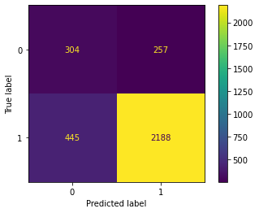

```
Plotting ROC curve
```

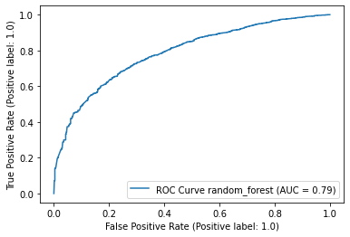

```
Writing Artifacts to MlFlow
Finished in 114.24255108833313 seconds
-------------------------------------------------------
Starting MlFlow run f3601937c1364e6cafd5ac52b11cfc31 for experiment 1

Training a multilayer_perceptron classifier
Best parameters:
{'classifier__activation': 'identity', 'classifier__alpha': 0.5}

Classification Report
```

|  | precision | recall | f1-score | support |
| --- | --- | --- | --- | --- |
| 0.0 | 0.237113 | 0.040998 | 0.069909 | 561.000000 |
| 1.0 | 0.826284 | 0.971895 | 0.893194 | 2633.000000 |
| accuracy | 0.808391 | 0.808391 | 0.808391 | 0.808391 |
| macro avg | 0.531698 | 0.506447 | 0.481551 | 3194.000000 |
| weighted avg | 0.722801 | 0.808391 | 0.748590 | 3194.000000 |

```
Plotting Confusion Matrix
```

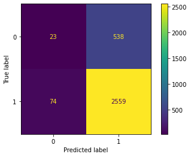

```
Plotting ROC curve
```

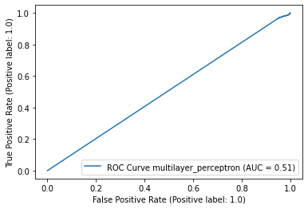

```
Writing Artifacts to MlFlow
Finished in 444.232382774353 seconds
-------------------------------------------------------
Starting MlFlow run 3baf0748603a4489aa2095494bc63611 for experiment 1

Training a gradient_boosting classifier
Best parameters:
{'classifier__learning_rate': 0.2, 'classifier__n_estimators': 200}

Classification Report
```

|  | precision | recall | f1-score | support |
| --- | --- | --- | --- | --- |
| 0.0 | 0.351731 | 0.670232 | 0.461350 | 561.00000 |
| 1.0 | 0.912941 | 0.736802 | 0.815469 | 2633.00000 |
| accuracy | 0.725110 | 0.725110 | 0.725110 | 0.72511 |
| macro avg | 0.632336 | 0.703517 | 0.638409 | 3194.00000 |
| weighted avg | 0.814369 | 0.725110 | 0.753271 | 3194.00000 |

```
Plotting Confusion Matrix
```

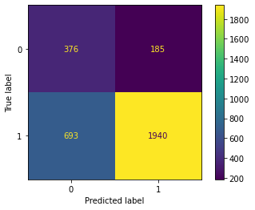

```
Plotting ROC curve
```

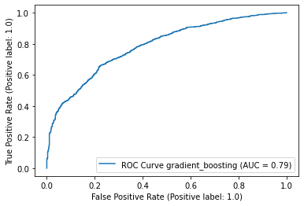

```
Writing Artifacts to MlFlow
Finished in 134.34181714057922 seconds
-------------------------------------------------------
```

```python
score_metric = "accuracy"
assert score_metric in ml_colon.SCORE_METRICS

run_id = None
mlflow.set_experiment("ml_colon_limited_features")
for classifier, _ in implemented_classifiers.items():
    run_id, experiment_id = run_model(classifier, X_train_limited_features, y_train, X_test_limited_features, y_test)
    print("-------------------------------------------------------")
```

```
INFO: 'ml_colon_all_features' does not exist. Creating a new experiment
Starting MlFlow run ae09502eec5b4253a8d8426fd21b7b87 for experiment 2

Training a k_neighbor classifier
Best parameters:
{'classifier__n_neighbors': 3}

Classification Report
```

|  | precision | recall | f1-score | support |
| --- | --- | --- | --- | --- |
| 0.0 | 0.277045 | 0.561497 | 0.371025 | 561.000000 |
| 1.0 | 0.880408 | 0.687809 | 0.772281 | 2633.000000 |
| accuracy | 0.665623 | 0.665623 | 0.665623 | 0.665623 |
| macro avg | 0.578727 | 0.624653 | 0.571653 | 3194.000000 |
| weighted avg | 0.774432 | 0.665623 | 0.701804 | 3194.000000 |

```
Plotting Confusion Matrix
```

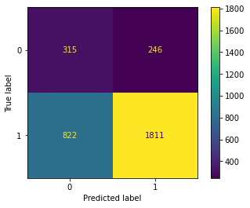

```
Plotting ROC curve
```

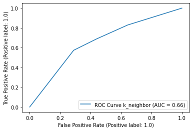

```
Writing Artifacts to MlFlow
Finished in 29.763580560684204 seconds
-------------------------------------------------------
Starting MlFlow run 5c3459883240437a98dced8f7e1ab44f for experiment 2

Training a random_forest classifier
Best parameters:
{'classifier__max_depth': 20, 'classifier__n_estimators': 45}

Classification Report
```

|  | precision | recall | f1-score | support |
| --- | --- | --- | --- | --- |
| 0.0 | 0.429986 | 0.541889 | 0.479495 | 561.000000 |
| 1.0 | 0.896663 | 0.846943 | 0.871094 | 2633.000000 |
| accuracy | 0.793363 | 0.793363 | 0.793363 | 0.793363 |
| macro avg | 0.663324 | 0.694416 | 0.675295 | 3194.000000 |
| weighted avg | 0.814695 | 0.793363 | 0.802313 | 3194.000000 |

```
Plotting Confusion Matrix
```

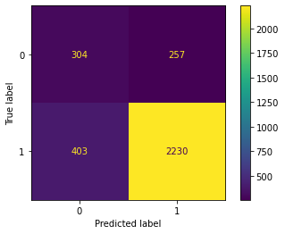

```
Plotting ROC curve
```

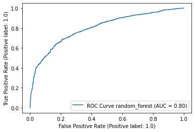

```
Writing Artifacts to MlFlow
Finished in 145.5228235721588 seconds
-------------------------------------------------------
Starting MlFlow run 88be3c4da6c04142923c958ece6fabaf for experiment 2

Training a multilayer_perceptron classifier
Best parameters:
{'classifier__activation': 'relu', 'classifier__alpha': 0.001}

Classification Report
```

|  | precision | recall | f1-score | support |
| --- | --- | --- | --- | --- |
| 0.0 | 0.230005 | 0.907308 | 0.366979 | 561.000000 |
| 1.0 | 0.946993 | 0.352829 | 0.514112 | 2633.000000 |
| accuracy | 0.450219 | 0.450219 | 0.450219 | 0.450219 |
| macro avg | 0.588499 | 0.630069 | 0.440545 | 3194.000000 |
| weighted avg | 0.821060 | 0.450219 | 0.488269 | 3194.000000 |

```
Plotting Confusion Matrix
```

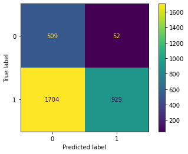

```
Plotting ROC curve
```

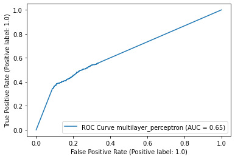

```
Writing Artifacts to MlFlow
Finished in 620.2100169658661 seconds
-------------------------------------------------------
Starting MlFlow run 1f06eeda763f49fba5e656fb5e16dae4 for experiment 2

Training a gradient_boosting classifier
Best parameters:
{'classifier__learning_rate': 0.2, 'classifier__n_estimators': 200}

Classification Report
```

|  | precision | recall | f1-score | support |
| --- | --- | --- | --- | --- |
| 0.0 | 0.370335 | 0.689840 | 0.481943 | 561.000000 |
| 1.0 | 0.919032 | 0.750095 | 0.826014 | 2633.000000 |
| accuracy | 0.739512 | 0.739512 | 0.739512 | 0.739512 |
| macro avg | 0.644684 | 0.719967 | 0.653978 | 3194.000000 |
| weighted avg | 0.822658 | 0.739512 | 0.765581 | 3194.000000 |

```
Plotting Confusion Matrix
```

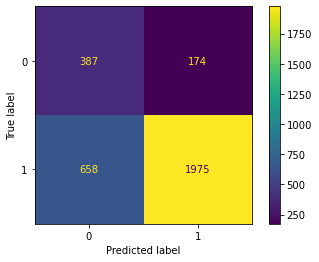

```
Plotting ROC curve
```

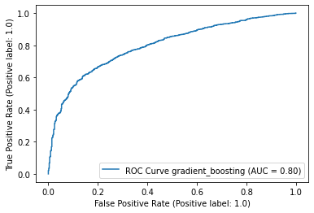

```
Writing Artifacts to MlFlow
Finished in 260.53609132766724 seconds
-------------------------------------------------------
```

```python
run_id = None
mlflow.set_experiment("ml_colon_all_features")
for classifier, _ in implemented_classifiers.items():
    run_id, experiment_id = run_model(classifier, X_train, y_train, X_test, y_test)
    print("-------------------------------------------------------")
```

### Compare Different Models

Once we have a few models trained we can compare their Receiver Operator Curve (ROC) to see how well perform.

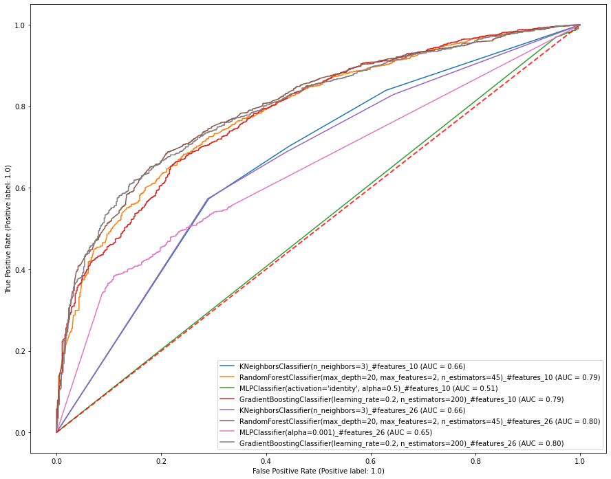

```python
fig, ax = plt.subplots(figsize=(15,12))

for model in trained_models:

    sklearn.metrics.plot_roc_curve(
    model['classifier'], model['X_test'], model['y_test'], name=f"{model['classifier'].best_estimator_.steps[-1][1]}_#features_{len(model['features'])}", ax=ax
    )

ax.plot([0, 1], [0, 1], linestyle='--', lw=2, color='r',
        label='Chance', alpha=.8)
```

#### MlFlow Dashboard

As explained in the `README.md` you can now run the MlFlow dashboard by executing

```
cd output/
mlflow ui
```

and then accessing the dashboard through your browser

### Loading a previously trained model

To load a previously trained model all one needs is to specify the run_id in which the model was trained.

```python
def load_model_from_run_id(experiment_id, run_id):
    model_path = ml_colon.OUTPUT_DIR / "mlruns" / str(experiment_id) / run_id / "artifacts" / "model.pkl"
    if not model_path.exists():
        print(f"Could not find pickled model under {model_path}")
        raise FileNotFoundError
    with open(model_path, "rb") as model_file:
        return pickle.load(model_file)
```

```python
reloaded_model = load_model_from_run_id(experiment_id, run_id)

print(reloaded_model.estimator)
```

```
Pipeline(steps=[('imputer', SimpleImputer()),
                ('scaler',
                 ColumnTransformer(remainder='passthrough',
                                   transformers=[('minmaxscaler',
                                                  MinMaxScaler(),
                                                  array([11, 12, 13, 14, 15, 16, 17, 18, 19, 20, 21, 22, 23, 24, 25]))])),
                ('classifier', GradientBoostingClassifier())])
```